# Challenges of a Bike Sharing Business Model

## Preliminary Wrangling

This is my project **"Communicate Data Findings"** in course of taking **Udacity's Data Analyst Nanodegree**.

A underlying data for this project, I chosed the data from **Ford GoBike System** which now is being operated by **Lyft** and just recently under the name [**baywheels**](https://www.lyft.com/bikes/bay-wheels).

### What Is Baywheels All About?

Since August 2013, baywheels and its predecessors (Motivate which cooperated with General Motors/Ford and which was then acquired by Lyft) offer bike sharing services in the Californian Bay Area in the USA, namely in

- San Francisco
- Easy Bay and
- San Jose

The offering of baywheels include short term rental services for bikes also known as bike sharing. The fleet currently consists of three types of bikes, docked standard bikes, docked electric-assistet bikes and dockless standard bikes with a rear-wheel lock (which are reported to be offered solely in San Jose).

The services are being offered to individual and corporate subscribers as well as for casual customers.

bayweels has a contract with the Bay's Metropolitan Transportation Commission which grants exclusive rights for bike sharing - however, just recently there started a dispute weather this is limited to docked bikes or not. This dispute is [reported to affect operations](https://www.fastcompany.com/90372239/in-s-f-lyfts-promise-of-better-bikeshare-hits-a-roadblock). Until today there's only competition by JUMP from Uber, which offers dockless bikes and e-bikes in a smaller pilot programm, but the City of San Francisco wants to significantly extend bike sharing (including dockless) and is aiming to more involve competitors. Also the deployment of brand-new [ebikes had severe problems](https://www.sfexaminer.com/news/lyft-electric-bike-catches-fire-in-sf/).

A brief description of the activities including a history of partners involved can also be found on [wikipedia](https://en.wikipedia.org/wiki/Bay_Wheels).

### Motivation

As I know from my hometown, Berlin/Germany, bike sharing is indeed a growing business. Bike sharing has a notion of being an environmentally friendly, healthy and fun alternative to other modes of transport.

However, I assume that bike sharing is also a challenging business model.

- Of course, it would be interesting if the data would show proof of the reported operational issues in connection with the legal dispute between baywheels and the City of San Francisco.
- Amongst others, a challenging aspect may be the operation of a decentralized system (even if it's at least partly bound to docks), where the bikes come in and go out kind of randomly and often must be reallocated.

### The Data

As I want to investigate on the challenges of a bike sharing business model, it is great that baywheels offers [system data here](https://www.lyft.com/bikes/bay-wheels/system-data).

Now, let's see if the data is helpful for my investigation, but first we'll need import some useful libraries for our quest:

```python
# Imports all packages and set plots to be embedded inline

# Imports from the standard library
import glob
import datetime

# Imports from packages
import numpy as np
import pandas as pd
import matplotlib.pyplot as plt
import seaborn as sb
from pandas.plotting import register_matplotlib_converters

# Plots embedded inline
%matplotlib inline

# Register matplotlib converter
register_matplotlib_converters()
sb.set()
```

Now, create and execute a function to load all zipped csvs from the folder:

```python
# Function to load all csvs from a folder into one dataframe
def concat_df_from_csvfolder(folder: str, **kwargs)-> pd.DataFrame:

    # Also working for compressed files
    if 'compression' in kwargs:
        extension = kwargs['compression']
    else:
        extension = 'csv'

    # Get list of csv paths in folder
    csvs = glob.glob(folder + '/*.' + extension)

    # Initialize list for dfs from csvs
    dfs = []

    # Iterate over list of csv paths
    for csv in csvs:

        # Get df from csv using kwargs
        df = pd.read_csv(csv, **kwargs)

        # Append df to dfs
        dfs.append(df)

    # Concatenate all dfs
    df = pd.concat(dfs,
                   axis=0,
                   ignore_index=True,
                   sort=False)

    return df
```

```python
# Read all csvs in folder 'data' to dataframe 'data'
# parsing 'start_time' and 'end_time' to datetime64[ns]-format
raw_data = concat_df_from_csvfolder(r'data',
                                    compression='zip',
                                    index_col=None,
                                    header=0,
                                    parse_dates=['start_time', 'end_time'],
                                    low_memory=False)
```

```python
# View samples of 'raw_data'
# (transposed for better readability)
raw_data.sample(5).T
```

|  | 3120954 | 3410379 | 373533 | 415271 | 270610 |
| --- | --- | --- | --- | --- | --- |
| duration_sec | 433 | 1351 | 756 | 596 | 956 |
| start_time | 2019-04-14 20:53:19.900000 | 2018-05-04 20:24:17.381000 | 2018-10-19 08:58:20.487000 | 2018-10-12 17:55:10.789000 | 2018-03-08 08:47:26.727000 |
| end_time | 2019-04-14 21:00:33.057000 | 2018-05-04 20:46:48.551000 | 2018-10-19 09:10:57.035000 | 2018-10-12 18:05:07.645000 | 2018-03-08 09:03:23.108000 |
| start_station_id | 181 | 323 | 67 | 308 | 25 |
| start_station_name | Grand Ave at Webster St | Broadway at Kearny | San Francisco Caltrain Station 2 (Townsend St... | San Pedro Square | Howard St at 2nd St |
| start_station_latitude | 37.8114 | 37.798 | 37.7766 | 37.3368 | 37.7875 |
| start_station_longitude | -122.265 | -122.406 | -122.396 | -121.894 | -122.397 |
| end_station_id | 215 | 4 | 77 | 316 | 125 |
| end_station_name | 34th St at Telegraph Ave | Cyril Magnin St at Ellis St | 11th St at Natoma St | San Salvador St at 1st St | 20th St at Bryant St |
| end_station_latitude | 37.8225 | 37.7859 | 37.7735 | 37.3302 | 37.7592 |
| end_station_longitude | -122.266 | -122.409 | -122.416 | -121.886 | -122.41 |
| bike_id | 3168 | 1715 | 1286 | 313 | 3567 |
| user_type | Subscriber | Customer | Subscriber | Subscriber | Subscriber |
| member_birth_year | 1988 | 1988 | 1993 | 1976 | 1967 |
| member_gender | Male | Male | Female | Female | Male |
| bike_share_for_all_trip | No | No | No | Yes | No |
| rental_access_method | NaN | NaN | NaN | NaN | NaN |

```python
# View basic info regarding 'raw_data'
raw_data.info(null_counts=True, memory_usage=True)
```

```
<class 'pandas.core.frame.DataFrame'>
RangeIndex: 3628260 entries, 0 to 3628259
Data columns (total 17 columns):
duration_sec               3628260 non-null int64
start_time                 3628260 non-null datetime64[ns]
end_time                   3628260 non-null datetime64[ns]
start_station_id           3613584 non-null float64
start_station_name         3613584 non-null object
start_station_latitude     3628260 non-null float64
start_station_longitude    3628260 non-null float64
end_station_id             3613482 non-null float64
end_station_name           3613482 non-null object
end_station_latitude       3628260 non-null float64
end_station_longitude      3628260 non-null float64
bike_id                    3628260 non-null int64
user_type                  3628260 non-null object
member_birth_year          3382488 non-null float64
member_gender              3383142 non-null object
bike_share_for_all_trip    3104667 non-null object
rental_access_method       3893 non-null object
dtypes: datetime64[ns](2), float64(7), int64(2), object(6)
memory usage: 470.6+ MB
```

```python
# View basic statistics regarding 'raw_data'
# (transposed for better readability)
raw_data.describe(include='all').T
```

|  | count | unique | top | freq | first | last | mean | std | min | 25% | 50% | 75% | max |
| --- | --- | --- | --- | --- | --- | --- | --- | --- | --- | --- | --- | --- | --- |
| duration_sec | 3.62826e+06 | NaN | NaN | NaN | NaN | NaN | 868.484 | 2414.82 | 60 | 353 | 560 | 876 | 86369 |
| start_time | 3628260 | 3628009 | 2018-07-12 22:43:30.235000 | 2 | 2017-06-28 09:47:36.347000 | 2019-06-30 23:58:44.099000 | NaN | NaN | NaN | NaN | NaN | NaN | NaN |
| end_time | 3628260 | 3628013 | 2018-08-28 09:18:24.866000 | 2 | 2017-06-28 09:52:55.338000 | 2019-07-01 16:57:45.592000 | NaN | NaN | NaN | NaN | NaN | NaN | NaN |
| start_station_id | 3.61358e+06 | NaN | NaN | NaN | NaN | NaN | 122.946 | 104.801 | 3 | 34 | 89 | 193 | 443 |
| start_station_name | 3613584 | 410 | San Francisco Caltrain Station 2 (Townsend St... | 75493 | NaN | NaN | NaN | NaN | NaN | NaN | NaN | NaN | NaN |
| start_station_latitude | 3.62826e+06 | NaN | NaN | NaN | NaN | NaN | 37.7682 | 0.103958 | 0 | 37.7711 | 37.7811 | 37.7954 | 45.51 |
| start_station_longitude | 3.62826e+06 | NaN | NaN | NaN | NaN | NaN | -122.352 | 0.159276 | -122.474 | -122.412 | -122.398 | -122.291 | 0 |
| end_station_id | 3.61348e+06 | NaN | NaN | NaN | NaN | NaN | 121.169 | 104.669 | 3 | 30 | 88 | 190 | 443 |
| end_station_name | 3613482 | 410 | San Francisco Caltrain Station 2 (Townsend St... | 100825 | NaN | NaN | NaN | NaN | NaN | NaN | NaN | NaN | NaN |
| end_station_latitude | 3.62826e+06 | NaN | NaN | NaN | NaN | NaN | 37.7682 | 0.132171 | 0 | 37.7711 | 37.7813 | 37.7962 | 45.51 |
| end_station_longitude | 3.62826e+06 | NaN | NaN | NaN | NaN | NaN | -122.351 | 0.308852 | -122.474 | -122.411 | -122.397 | -122.294 | 0 |
| bike_id | 3.62826e+06 | NaN | NaN | NaN | NaN | NaN | 3108.88 | 15879.4 | 10 | 1291 | 2503 | 3666 | 985110 |
| user_type | 3628260 | 2 | Subscriber | 3062494 | NaN | NaN | NaN | NaN | NaN | NaN | NaN | NaN | NaN |
| member_birth_year | 3.38249e+06 | NaN | NaN | NaN | NaN | NaN | 1983.29 | 10.4277 | 1878 | 1978 | 1986 | 1991 | 2001 |
| member_gender | 3383142 | 7 | Male | 2507982 | NaN | NaN | NaN | NaN | NaN | NaN | NaN | NaN | NaN |
| bike_share_for_all_trip | 3104667 | 2 | No | 2837995 | NaN | NaN | NaN | NaN | NaN | NaN | NaN | NaN | NaN |
| rental_access_method | 3893 | 2 | app | 3379 | NaN | NaN | NaN | NaN | NaN | NaN | NaN | NaN | NaN |

```python
# Find out about the distinct locations with regard to latitude and longitude?
raw_data[['start_station_longitude', 'start_station_latitude', 'end_station_longitude', 'end_station_latitude']].nunique()
```

```
start_station_longitude    2622
start_station_latitude     2610
end_station_longitude      2719
end_station_latitude       2712
dtype: int64
```

*Interim Conclusion(s):*

- There are many more locations defined by latitude and longitude, than by id and name.
- This possibly relates to the fact that there are also "dockless" bikes (operated in San Jose).

```python
# Find out about uniques bike_ids
raw_data.bike_id.nunique()
```

```
7180
```

```python
# Find out about the user_type values
raw_data.user_type.drop_duplicates()
```

```
0      Customer
3    Subscriber
Name: user_type, dtype: object
```

*Interim Conclusion(s):*  
The two user types are subscribers and customers (= non-subscribers)

```python
# Find out about the member_gender values
raw_data.member_gender.drop_duplicates()
```

```
0            Male
1             NaN
3           Other
6          Female
3014053         M
3014072         ?
3014082         F
3014359         O
Name: member_gender, dtype: object
```

*Interim Conclusion(s):*

- There are four types of "genders": Male/M, Female/F, Other/O and NaN/?

```python
# Find out about the bike_share_for_all_trip values
raw_data.bike_share_for_all_trip.drop_duplicates()
```

```
0          No
4         Yes
878437    NaN
Name: bike_share_for_all_trip, dtype: object
```

```python
# Find out about logical relation between user_type and bike_share_for_all
raw_data[['user_type', 'bike_share_for_all_trip']].drop_duplicates()
```

|  | user_type | bike_share_for_all_trip |
| --- | --- | --- |
| 0 | Customer | No |
| 3 | Subscriber | No |
| 4 | Subscriber | Yes |
| 878437 | Customer | NaN |
| 878441 | Subscriber | NaN |

```python
# Find out about the time span of bike_share_for_all_trip
raw_data[raw_data.bike_share_for_all_trip.isna()]['start_time'].max(), raw_data[raw_data.bike_share_for_all_trip.notna()]['start_time'].min()
```

```
(Timestamp('2019-06-27 16:51:14'), Timestamp('2018-01-01 00:01:53.847000'))
```

*Interim Conclusion(s)*:

- There are no "Customers"/non-users that are "bike share for all" users.
- All "bike share for all users" are subscribers.
- The "bike share for all" offer started with 2018, before there is no information
- So, the "bike share for all" program can be seen as a special kind of subscription.

### Structure of the dataset

The dataset retrieved from 19 csvs/zips from baywheels contains information for **3.628.260 trips/rows** with the following **17 attributes/columns**:

| **Attribute** | Description | *Strategy* |
| --- | --- | --- |
| **'duration_sec'** | Duration of the ride in seconds | *Keep* |
| **'start_time'** | Start time of the ride | *Keep, convert to Timedelta* |
| **'end_time'** | Id of the station where the ride started | *Eliminate (possible redundancy to 'start_time' and 'duration'* |
| **'start_station_id'** | Name of the station where the ride started | *Eliminate, rely on 'start_latitude' and 'start_longitude'* |
| **'start_station_name'** | Name of the station where the ride started | *Eliminate, rely on 'start_latitude' and 'start_longitude'* |
| **'start_station_latitude'** | Geografical latitude of the station where the ride started | *Keep* |
| **'start_station_longitude'** | Geografical longitude of the station where the ride started | *Keep* |
| **'end_station_id'** | Id of the station where the ride started | *Eliminate, rely on 'end_latitude' and 'end_longitude'* |
| **'end_station_name'** | Name of the station where the ride started | *Eliminate, rely on 'end_latitude' and 'end_longitude'* |
| **'end_station_latitude'** | Geografical latitude of the station where the ride started | *Keep* |
| **'end_station_longitude'** | Geografical longitude of the station where the ride started | *Keep* |
| **'bike_id'** | Id of the bike | *Keep* |
| **'user_type'** | Type of the user (being 'Subscriber' or 'Customer'/casual rider | *Keep, convert to category* |
| **'member_birth_year'** | Year of birth of the user | *Keep* |
| **'member_gender'** | Gender of the user | *Keep; convert to category* |
| **'bike_share_for_all_trip'** | User being a member of the 'Bike Share for All' program (special subscription program) | *Keep; convert to category; inner structure with 'user_type'* |
| **'rental_access_method'** | Interface the rental contract is being generated with | *Eliminate as it was introduced in 06/2019* |

In order to simplify the further analysis, I first create a new dataframe 'trip_data' with columns according to the defined strategy:

```python
# Create new dataframe dropping end_time, start_station_id, start_station_name, end_station_id, end_station_name
# and renaming and resorting the remaining columns

trip_data = raw_data.drop(['end_time',
                           'start_station_id',
                           'start_station_name',
                           'end_station_id',
                           'end_station_name'],
                          axis=1)

trip_data.columns = ['duration',
                     'start_time',
                     'start_lat',
                     'start_long',
                     'end_lat',
                     'end_long',
                     'bike',
                     'subscriber',
                     'birth_year',
                     'gender',
                     'bsfa_subscriber',
                     'rental_access_method']

trip_data = trip_data[['subscriber',
                       'bsfa_subscriber',
                       'gender',
                       'birth_year',

                       'start_time',
                       'duration',

                       'start_lat',
                       'start_long',
                       'end_lat',
                       'end_long',
                       'bike']]
```

```python
# Map user values
trip_data.subscriber.replace({'Subscriber': True, 'Customer': False}, inplace=True)
trip_data.bsfa_subscriber.replace({'Yes': True, 'No': False, np.NaN: False}, inplace=True)
trip_data.gender.replace({np.NaN: 'Unknown'}, inplace=True)
trip_data.gender.replace({'M': 'Male', 'F': 'Female', 'O': 'Other', '?': 'Unknown'}, inplace=True)
```

```python
# Downsize int for bike to necessary size
trip_data.bike = trip_data.bike.astype('int32')

# Set gender as category
trip_data.gender = trip_data.gender.astype('category')

# Reducing precision of time data to minutes
trip_data.start_time = trip_data.start_time.astype('datetime64[m]')
trip_data.duration = pd.to_timedelta((trip_data.duration/60).apply(np.floor)*60, unit='s')

# Reduce precision of lat/long to around 0.0002 (which only is approx. 60 feet)
trip_data[['start_lat', 'start_long', 'end_lat', 'end_long']] = (trip_data[['start_lat', 'start_long', 'end_lat', 'end_long']] / 2).round(4) * 2
```

```python
trip_data.describe(include='all').T.fillna('-')
```

|  | count | unique | top | freq | first | last | mean | std | min | 25% | 50% | 75% | max |
| --- | --- | --- | --- | --- | --- | --- | --- | --- | --- | --- | --- | --- | --- |
| subscriber | 3628260.0 | 2 | True | 3062494 | - | - | - | - | - | - | - | - | - |
| bsfa_subscriber | 3628260.0 | 2 | False | 3361588 | - | - | - | - | - | - | - | - | - |
| gender | 3628260.0 | 4 | Male | 2510449 | - | - | - | - | - | - | - | - | - |
| birth_year | 3382488.0 | - | - | - | - | - | 1983.29 | 10.4277 | 1878 | 1978 | 1986 | 1991 | 2001 |
| start_time | 3628260.0 | 725779 | 2019-04-09 08:31:00 | 52 | 2017-06-28 09:47:00 | 2019-06-30 23:58:00 | - | - | - | - | - | - | - |
| duration | 3628260.0 | - | - | - | - | - | 0 days 00:13:59.002282 | 0 days 00:40:14.882619 | 0 days 00:01:00 | 0 days 00:05:00 | 0 days 00:09:00 | 0 days 00:14:00 | 0 days 23:59:00 |
| start_lat | 3628260.0 | - | - | - | - | - | 37.7682 | 0.103958 | 0 | 37.771 | 37.781 | 37.7954 | 45.51 |
| start_long | 3628260.0 | - | - | - | - | - | -122.352 | 0.159273 | -122.474 | -122.412 | -122.398 | -122.291 | 0 |
| end_lat | 3628260.0 | - | - | - | - | - | 37.7682 | 0.13217 | 0 | 37.771 | 37.7812 | 37.7962 | 45.51 |
| end_long | 3628260.0 | - | - | - | - | - | -122.351 | 0.308851 | -122.474 | -122.411 | -122.397 | -122.294 | 0 |
| bike | 3628260.0 | - | - | - | - | - | 3108.88 | 15879.4 | 10 | 1291 | 2503 | 3666 | 985110 |

### Feature(s) of interest

As my pursuit is rather broad and it's less about finding the drivers of one single feature, all features (user related ones, time related ones and location related ones) will play a role.

Now, let's start the investigation:

## Univariate Exploration

### User Related Features:

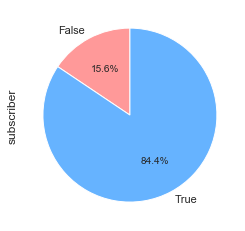

```python
# Data extraction
data = trip_data.subscriber.value_counts(ascending=True)

# Data plotting
data.plot(kind='pie', startangle=90, autopct='%1.1f%%', colors=['#ff9999','#66b3ff']);
```

*Interim Conclusion(s):*  
More than 5/6 of the users are subscribers.

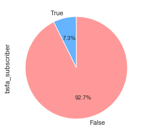

```python
data = trip_data.bsfa_subscriber.value_counts(ascending=True)
data.plot(kind='pie', startangle=90, autopct='%1.1f%%', colors=['#66b3ff', '#ff9999']);
```

*Interim Conclusion(s):*  
Only a small portion of subscribers are a 'bike share for all subscribers'

*Next*:  
Narrow 'bike_share_for_all' users to subscribers (as they are all subscribers):

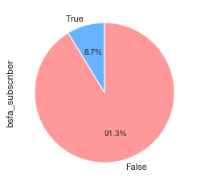

```python
data = trip_data[trip_data.subscriber == True].bsfa_subscriber.value_counts(ascending=True)
data.plot(kind='pie', startangle=90, autopct='%1.1f%%', colors=['#66b3ff', '#ff9999']);
```

*Interim Conclusion(s):*

- Only 9% of all subscribers are also 'bike share for all' subscribers.

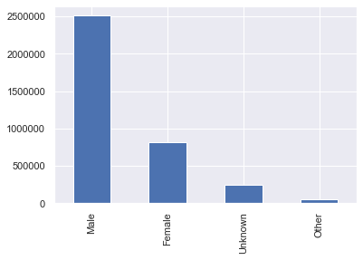

```python
data = trip_data.gender.value_counts()
data.plot(kind='bar');
```

*Interim Conclusion(s):*

- Most users are male.
- A not unsignificant proportion of users has an unknown gender.

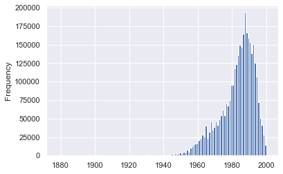

```python
data = trip_data.birth_year
data.plot(kind='hist', bins=int(data.max() - data.min() + 1));
```

*Interim Conclusion(s):*

- Typical users are born between 1960 and 2000.
- Some (although very few) birth year data are obviously non-sense (users older than 90 years old??)

*Next (for non-univariate exploration):*

- See how user related features are interrelated (especially with regard to being user or not).

### Time Related Features:

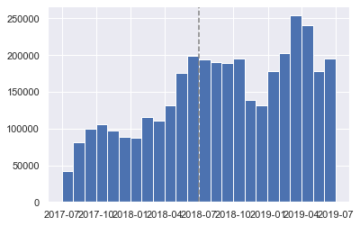

```python
data = trip_data.start_time[(trip_data.start_time >= '2017-07-01') &
                            (trip_data.start_time < '2019-07-01')]
plt.hist(data, bins=24)
plt.axvline(x='07-01-2018', color='grey', linestyle='--');
```

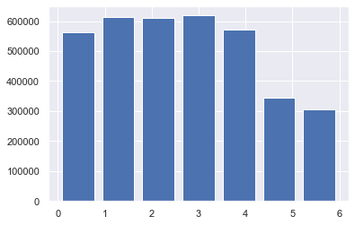

```python
data = trip_data.start_time.dt.dayofweek
plt.hist(data, bins=7, rwidth=0.8);
```

*Interim Conclusion(s):*

- There are almost twice as much trips on weekdays than on weekends.
- This may be a hint that most users, use the bikes to get to work.

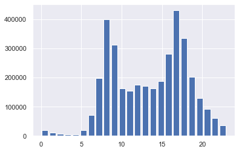

```python
data = trip_data.start_time.dt.hour
plt.hist(data, bins=24, rwidth=0.8);
```

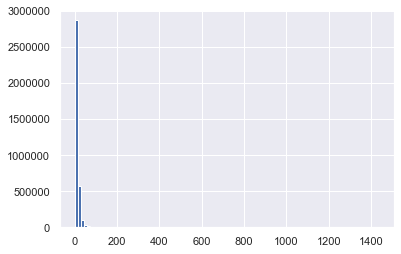

```python
data = trip_data.duration.dt.total_seconds() / 60
plt.hist(data, bins=100);
```

*Interim Conclusion(s):*

- Most trips are rather short (only a few minutes)
- However, some trips comprise almost a day.

*Next:*  
See log of 'duration'.

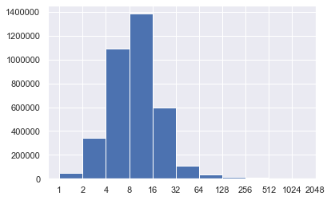

```python
# Duration in minutes rather than seconds
data = trip_data.duration.dt.total_seconds() / 60

# Bins for every doubling of 1 minute
bin_edges = 2 ** np.arange(0, np.log2(2048), 1)

# Create plot
plt.hist(data, bins=bin_edges)

# Scale the plot (minimum duration actually is 61 sec > 1 min)
plt.xscale('log', basex=2)
xtick_locs = [1, 2, 4, 8, 16, 32, 64, 128, 256, 512, 1024, 2048]
plt.xticks(xtick_locs, xtick_locs);
```

*Interim Conclusion(s):*

- Most trips last beween 4 and 16 minutes - a timeframe most trips only cost a basis fee.

*Next (for non-univariate exploration):*

- See how time related features are interrelated, especially:
  - Is usage over the day and duration of trips changing with time?
- See how user related features relate to time related features, especially:
  - How's the development over time with subscribers/non-subscribers?
  - Is there a different pattern of usage during the day for subscribers/non-subscribers?

### Location Related Features:

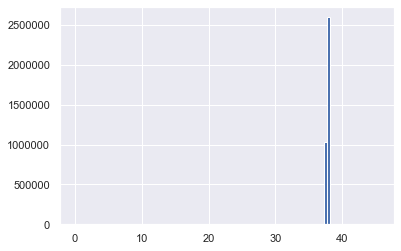

```python
data = trip_data.start_lat
data.hist(bins=100);
```

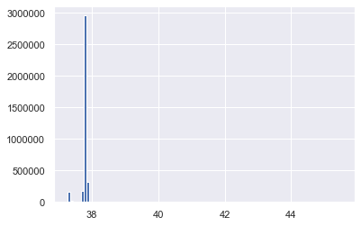

```python
data = trip_data[trip_data.start_lat > 35].start_lat
data.hist(bins=100);
```

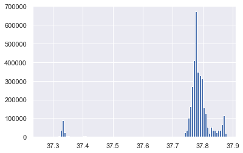

```python
data = trip_data[
    (trip_data.start_lat > 35) & (trip_data.start_lat < 39)].start_lat
data.hist(bins=100);
```

```python
data = trip_data[
    (trip_data.start_lat < 35) | (trip_data.start_lat > 39) |
    (trip_data.end_lat < 35) | (trip_data.end_lat > 39)
]
data
```

|  | subscriber | bsfa_subscriber | gender | birth_year | start_time | duration | start_lat | start_long | end_lat | end_long | bike |
| --- | --- | --- | --- | --- | --- | --- | --- | --- | --- | --- | --- |
| 506552 | True | False | Male | 1977.0 | 2018-06-29 08:57:00 | 00:04:00 | 45.5100 | -73.5700 | 45.5100 | -73.5700 | 4295 |
| 528170 | True | False | Female | 1981.0 | 2018-06-26 10:59:00 | 03:35:00 | 44.9500 | -93.2200 | 44.9500 | -93.2200 | 3758 |
| 553144 | True | False | Male | 1977.0 | 2018-06-22 13:36:00 | 00:24:00 | 45.5100 | -73.5700 | 45.5100 | -73.5700 | 4295 |
| 630908 | True | False | Male | 1989.0 | 2018-06-11 08:23:00 | 00:03:00 | 45.5100 | -73.5700 | 45.5100 | -73.5700 | 4295 |
| 689109 | True | False | Male | 1976.0 | 2018-06-01 13:56:00 | 00:01:00 | 40.6600 | -74.0100 | 40.6600 | -74.0100 | 4297 |
| 689126 | True | False | Male | 1987.0 | 2018-06-01 13:51:00 | 00:02:00 | 40.6600 | -74.0100 | 40.6600 | -74.0100 | 4297 |
| 689147 | True | False | Male | 1987.0 | 2018-06-01 13:47:00 | 00:01:00 | 40.6600 | -74.0100 | 40.6600 | -74.0100 | 4297 |
| 2343536 | True | False | Male | 1980.0 | 2018-08-21 12:11:00 | 00:08:00 | 45.5000 | -73.5700 | 45.5100 | -73.5700 | 4425 |
| 2350376 | True | False | Male | 1980.0 | 2018-08-20 12:07:00 | 00:17:00 | 45.5000 | -73.5700 | 45.5100 | -73.5700 | 4425 |
| 2350974 | True | False | Male | 1980.0 | 2018-08-20 09:53:00 | 00:01:00 | 45.5100 | -73.5700 | 45.5100 | -73.5700 | 4425 |
| 2392424 | True | False | Male | 1987.0 | 2018-08-13 11:23:00 | 01:03:00 | 44.9500 | -93.2200 | 44.9500 | -93.2200 | 3763 |
| 2847304 | True | False | Other | NaN | 2019-06-27 07:31:00 | 01:10:00 | 45.5100 | -73.5700 | 45.5100 | -73.5700 | 6733 |
| 3019119 | True | False | Female | 1995.0 | 2019-04-30 18:21:00 | 00:39:00 | 37.7806 | -122.3902 | 0.0000 | 0.0000 | 1612 |
| 3019885 | True | False | Female | 1981.0 | 2019-04-30 17:31:00 | 00:32:00 | 37.7650 | -122.4218 | 0.0000 | 0.0000 | 3507 |
| 3020039 | True | True | Female | 1991.0 | 2019-04-30 17:45:00 | 00:09:00 | 37.7874 | -122.4132 | 0.0000 | 0.0000 | 1142 |
| 3020118 | True | False | Male | 1991.0 | 2019-04-30 17:39:00 | 00:10:00 | 37.7896 | -122.4008 | 0.0000 | 0.0000 | 3500 |
| 3020571 | True | False | Male | 1995.0 | 2019-04-30 17:17:00 | 00:07:00 | 37.7972 | -122.3984 | 0.0000 | 0.0000 | 1181 |
| 3020654 | True | False | Male | 1970.0 | 2019-04-30 16:58:00 | 00:20:00 | 37.7758 | -122.3932 | 0.0000 | 0.0000 | 2535 |
| 3020686 | True | False | Male | 1992.0 | 2019-04-30 16:55:00 | 00:21:00 | 37.7752 | -122.3974 | 0.0000 | 0.0000 | 462 |
| 3020977 | False | False | Male | 1976.0 | 2019-04-30 16:44:00 | 00:12:00 | 37.7942 | -122.3944 | 0.0000 | 0.0000 | 1880 |
| 3033228 | False | False | Male | 1981.0 | 2019-04-28 18:40:00 | 00:24:00 | 37.7720 | -122.4538 | 0.0000 | 0.0000 | 150 |
| 3033281 | True | False | Female | 1981.0 | 2019-04-28 18:40:00 | 00:11:00 | 37.7510 | -122.4120 | 0.0000 | 0.0000 | 311 |
| 3033396 | False | False | Male | 1989.0 | 2019-04-28 18:10:00 | 00:12:00 | 37.7328 | -122.4342 | 0.0000 | 0.0000 | 333 |
| 3033397 | False | False | Male | 1989.0 | 2019-04-28 18:08:00 | 00:15:00 | 37.7328 | -122.4342 | 0.0000 | 0.0000 | 2760 |
| 3033428 | True | False | Male | 1997.0 | 2019-04-28 17:52:00 | 00:25:00 | 37.7720 | -122.4538 | 0.0000 | 0.0000 | 3632 |
| 3033429 | True | False | Male | 1995.0 | 2019-04-28 17:52:00 | 00:25:00 | 37.7720 | -122.4538 | 0.0000 | 0.0000 | 901 |
| 3033448 | True | False | Male | 1981.0 | 2019-04-28 18:00:00 | 00:14:00 | 37.7700 | -122.4118 | 0.0000 | 0.0000 | 536 |
| 3058622 | True | False | Male | 1983.0 | 2019-04-24 16:56:00 | 00:02:00 | 0.0000 | 0.0000 | 37.7758 | -122.3932 | 1161 |
| 3058664 | True | False | Female | 1970.0 | 2019-04-24 16:53:00 | 00:03:00 | 37.7670 | -122.3908 | 0.0000 | 0.0000 | 3498 |
| 3067561 | True | False | Male | 1967.0 | 2019-04-23 13:14:00 | 00:15:00 | 37.7912 | -122.3990 | 0.0000 | 0.0000 | 1768 |
| 3105762 | True | False | Male | 1982.0 | 2019-04-17 09:30:00 | 00:15:00 | 37.8026 | -122.4362 | 0.0000 | 0.0000 | 1939 |

*Interim Conclusion(s):*

- 'start_latitude' (mostly) is around 37.3 to 37.9, having three peaks that probably relate to San Francisco, East Bay and San Jose (the operating areas)
- However, there are very few, but severe outliers.

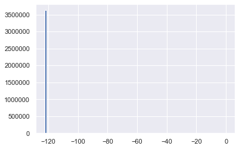

```python
data = trip_data.start_long
data.hist(bins=100);
```

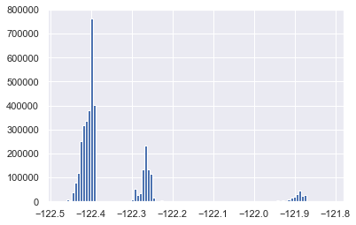

```python
data = trip_data[trip_data.start_long < -120].start_long
data.hist(bins=100);
```

```python
data = trip_data[(trip_data.start_long > -120) | (trip_data.end_long > -120)]
data
```

|  | subscriber | bsfa_subscriber | gender | birth_year | start_time | duration | start_lat | start_long | end_lat | end_long | bike |
| --- | --- | --- | --- | --- | --- | --- | --- | --- | --- | --- | --- |
| 506552 | True | False | Male | 1977.0 | 2018-06-29 08:57:00 | 00:04:00 | 45.5100 | -73.5700 | 45.5100 | -73.5700 | 4295 |
| 528170 | True | False | Female | 1981.0 | 2018-06-26 10:59:00 | 03:35:00 | 44.9500 | -93.2200 | 44.9500 | -93.2200 | 3758 |
| 553144 | True | False | Male | 1977.0 | 2018-06-22 13:36:00 | 00:24:00 | 45.5100 | -73.5700 | 45.5100 | -73.5700 | 4295 |
| 630908 | True | False | Male | 1989.0 | 2018-06-11 08:23:00 | 00:03:00 | 45.5100 | -73.5700 | 45.5100 | -73.5700 | 4295 |
| 689109 | True | False | Male | 1976.0 | 2018-06-01 13:56:00 | 00:01:00 | 40.6600 | -74.0100 | 40.6600 | -74.0100 | 4297 |
| 689126 | True | False | Male | 1987.0 | 2018-06-01 13:51:00 | 00:02:00 | 40.6600 | -74.0100 | 40.6600 | -74.0100 | 4297 |
| 689147 | True | False | Male | 1987.0 | 2018-06-01 13:47:00 | 00:01:00 | 40.6600 | -74.0100 | 40.6600 | -74.0100 | 4297 |
| 2343536 | True | False | Male | 1980.0 | 2018-08-21 12:11:00 | 00:08:00 | 45.5000 | -73.5700 | 45.5100 | -73.5700 | 4425 |
| 2350376 | True | False | Male | 1980.0 | 2018-08-20 12:07:00 | 00:17:00 | 45.5000 | -73.5700 | 45.5100 | -73.5700 | 4425 |
| 2350974 | True | False | Male | 1980.0 | 2018-08-20 09:53:00 | 00:01:00 | 45.5100 | -73.5700 | 45.5100 | -73.5700 | 4425 |
| 2392424 | True | False | Male | 1987.0 | 2018-08-13 11:23:00 | 01:03:00 | 44.9500 | -93.2200 | 44.9500 | -93.2200 | 3763 |
| 2847304 | True | False | Other | NaN | 2019-06-27 07:31:00 | 01:10:00 | 45.5100 | -73.5700 | 45.5100 | -73.5700 | 6733 |
| 3019119 | True | False | Female | 1995.0 | 2019-04-30 18:21:00 | 00:39:00 | 37.7806 | -122.3902 | 0.0000 | 0.0000 | 1612 |
| 3019885 | True | False | Female | 1981.0 | 2019-04-30 17:31:00 | 00:32:00 | 37.7650 | -122.4218 | 0.0000 | 0.0000 | 3507 |
| 3020039 | True | True | Female | 1991.0 | 2019-04-30 17:45:00 | 00:09:00 | 37.7874 | -122.4132 | 0.0000 | 0.0000 | 1142 |
| 3020118 | True | False | Male | 1991.0 | 2019-04-30 17:39:00 | 00:10:00 | 37.7896 | -122.4008 | 0.0000 | 0.0000 | 3500 |
| 3020571 | True | False | Male | 1995.0 | 2019-04-30 17:17:00 | 00:07:00 | 37.7972 | -122.3984 | 0.0000 | 0.0000 | 1181 |
| 3020654 | True | False | Male | 1970.0 | 2019-04-30 16:58:00 | 00:20:00 | 37.7758 | -122.3932 | 0.0000 | 0.0000 | 2535 |
| 3020686 | True | False | Male | 1992.0 | 2019-04-30 16:55:00 | 00:21:00 | 37.7752 | -122.3974 | 0.0000 | 0.0000 | 462 |
| 3020977 | False | False | Male | 1976.0 | 2019-04-30 16:44:00 | 00:12:00 | 37.7942 | -122.3944 | 0.0000 | 0.0000 | 1880 |
| 3033228 | False | False | Male | 1981.0 | 2019-04-28 18:40:00 | 00:24:00 | 37.7720 | -122.4538 | 0.0000 | 0.0000 | 150 |
| 3033281 | True | False | Female | 1981.0 | 2019-04-28 18:40:00 | 00:11:00 | 37.7510 | -122.4120 | 0.0000 | 0.0000 | 311 |
| 3033396 | False | False | Male | 1989.0 | 2019-04-28 18:10:00 | 00:12:00 | 37.7328 | -122.4342 | 0.0000 | 0.0000 | 333 |
| 3033397 | False | False | Male | 1989.0 | 2019-04-28 18:08:00 | 00:15:00 | 37.7328 | -122.4342 | 0.0000 | 0.0000 | 2760 |
| 3033428 | True | False | Male | 1997.0 | 2019-04-28 17:52:00 | 00:25:00 | 37.7720 | -122.4538 | 0.0000 | 0.0000 | 3632 |
| 3033429 | True | False | Male | 1995.0 | 2019-04-28 17:52:00 | 00:25:00 | 37.7720 | -122.4538 | 0.0000 | 0.0000 | 901 |
| 3033448 | True | False | Male | 1981.0 | 2019-04-28 18:00:00 | 00:14:00 | 37.7700 | -122.4118 | 0.0000 | 0.0000 | 536 |
| 3058622 | True | False | Male | 1983.0 | 2019-04-24 16:56:00 | 00:02:00 | 0.0000 | 0.0000 | 37.7758 | -122.3932 | 1161 |
| 3058664 | True | False | Female | 1970.0 | 2019-04-24 16:53:00 | 00:03:00 | 37.7670 | -122.3908 | 0.0000 | 0.0000 | 3498 |
| 3067561 | True | False | Male | 1967.0 | 2019-04-23 13:14:00 | 00:15:00 | 37.7912 | -122.3990 | 0.0000 | 0.0000 | 1768 |
| 3105762 | True | False | Male | 1982.0 | 2019-04-17 09:30:00 | 00:15:00 | 37.8026 | -122.4362 | 0.0000 | 0.0000 | 1939 |

*Interim Conclusion(s):*

- 'start_latitude' (mostly) is around -122.5 to -121.8, having three peaks that probably relate to San Francisco, East Bay and San Jose (the operating areas).
- However, there are very few, but severe outliers.

*Next (for non-bivariate exploration):*

- Analyse futher to see the 2d structure of the locations and to create "areas" for further analysis.

### Interim Summary:

- Most users are subscribers, but it might be worthwhile to investigate on different user patterns anyway.
- The general growth was impacted by a downturn in May/June 2019. This should be further investigated.
- Latitude and longitude can be used to create maps and to identify areas

## Bivariate Exploration

### Interrelation of User Related Features:

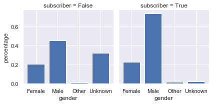

```python
data = trip_data[['subscriber', 'gender', 'bike']]
data = pd.crosstab(data['subscriber'],data['gender']).apply(lambda r: r/r.sum(), axis=1).stack().reset_index()
data.columns = ['subscriber', 'gender', 'percentage']

g = sb.FacetGrid(data=data, col='subscriber')
g.map(plt.bar, 'gender', 'percentage');
```

*Interim Conclusion(s):*  
As the proportion of "Female" and "Other" users look quite comparable with subscribers and non-subscribers, it looks a bit like fewer man are willing to share their gender information when not being a subscriber.

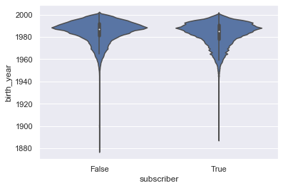

```python
data = trip_data[['subscriber', 'birth_year']]
sb.violinplot(data=data, x='subscriber', y='birth_year', color=sb.color_palette()[0]);
```

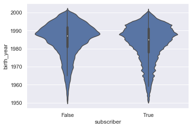

```python
data = trip_data[['subscriber', 'birth_year']][trip_data.birth_year > 1950]
sb.violinplot(data=data, x='subscriber', y='birth_year', color=sb.color_palette()[0])
```

*Interim Conclusion(s):*  
When narrowed down to the majority of the users birth years (>1950), we see that subscribers are a bit older than non-subscribers.

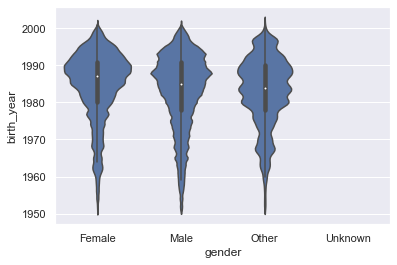

```python
data = trip_data[['gender', 'birth_year']][trip_data.birth_year > 1950]
sb.violinplot(data=data, x='gender', y='birth_year', color=sb.color_palette()[0])
```

```python
trip_data[trip_data.gender == 'Unknown']['birth_year'].value_counts()
```

```
Series([], Name: birth_year, dtype: int64)
```

```python
trip_data[trip_data.gender != 'Unknown'][trip_data[trip_data.gender != 'Unknown'].birth_year.isna()]
```

|  | subscriber | bsfa_subscriber | gender | birth_year | start_time | duration | start_lat | start_long | end_lat | end_long | bike |
| --- | --- | --- | --- | --- | --- | --- | --- | --- | --- | --- | --- |
| 188149 | True | False | Female | NaN | 2018-03-30 15:31:00 | 00:17:00 | 37.7704 | -122.3912 | 37.7954 | -122.3942 | 2540 |
| 190181 | True | False | Female | NaN | 2018-03-30 08:25:00 | 00:18:00 | 37.7898 | -122.3946 | 37.7704 | -122.3912 | 2766 |
| 192922 | True | False | Female | NaN | 2018-03-29 16:59:00 | 00:19:00 | 37.7704 | -122.3912 | 37.7942 | -122.3944 | 2859 |
| 195405 | True | False | Female | NaN | 2018-03-29 08:30:00 | 00:21:00 | 37.7898 | -122.3946 | 37.7704 | -122.3912 | 1627 |
| 197958 | True | False | Female | NaN | 2018-03-28 17:24:00 | 00:18:00 | 37.7704 | -122.3912 | 37.7954 | -122.3942 | 3371 |
| 200836 | True | False | Female | NaN | 2018-03-28 08:19:00 | 00:20:00 | 37.7898 | -122.3946 | 37.7704 | -122.3912 | 2572 |
| 203092 | True | False | Female | NaN | 2018-03-27 17:38:00 | 00:20:00 | 37.7704 | -122.3912 | 37.7954 | -122.3942 | 1756 |
| 205874 | True | False | Female | NaN | 2018-03-27 08:31:00 | 00:20:00 | 37.7922 | -122.3970 | 37.7704 | -122.3912 | 1578 |
| 218376 | True | False | Female | NaN | 2018-03-23 13:27:00 | 00:16:00 | 37.7704 | -122.3912 | 37.7954 | -122.3942 | 689 |
| 219722 | True | False | Female | NaN | 2018-03-23 08:25:00 | 00:23:00 | 37.7898 | -122.3946 | 37.7704 | -122.3912 | 357 |
| 221843 | True | False | Female | NaN | 2018-03-22 17:21:00 | 00:18:00 | 37.7704 | -122.3912 | 37.7954 | -122.3942 | 1541 |
| 223721 | True | False | Female | NaN | 2018-03-22 08:34:00 | 00:23:00 | 37.7898 | -122.3946 | 37.7704 | -122.3912 | 3168 |
| 225599 | True | False | Female | NaN | 2018-03-21 17:16:00 | 00:15:00 | 37.7704 | -122.3912 | 37.7954 | -122.3942 | 1640 |
| 227603 | True | False | Female | NaN | 2018-03-21 08:27:00 | 00:20:00 | 37.7898 | -122.3946 | 37.7704 | -122.3912 | 2139 |
| 229032 | True | False | Female | NaN | 2018-03-20 17:44:00 | 00:16:00 | 37.7704 | -122.3912 | 37.7954 | -122.3942 | 3302 |
| 230457 | True | False | Female | NaN | 2018-03-20 08:24:00 | 00:17:00 | 37.7898 | -122.3946 | 37.7704 | -122.3912 | 491 |
| 232601 | True | False | Female | NaN | 2018-03-19 17:21:00 | 00:18:00 | 37.7704 | -122.3912 | 37.7954 | -122.3942 | 713 |
| 235130 | True | False | Female | NaN | 2018-03-19 08:33:00 | 00:19:00 | 37.7898 | -122.3946 | 37.7704 | -122.3912 | 3358 |
| 244510 | True | False | Female | NaN | 2018-03-15 17:32:00 | 00:16:00 | 37.7704 | -122.3912 | 37.7954 | -122.3942 | 189 |
| 246333 | True | False | Female | NaN | 2018-03-15 08:29:00 | 00:19:00 | 37.7898 | -122.3946 | 37.7704 | -122.3912 | 521 |
| 248452 | True | False | Female | NaN | 2018-03-14 17:37:00 | 00:16:00 | 37.7704 | -122.3912 | 37.7954 | -122.3942 | 670 |
| 250554 | True | False | Female | NaN | 2018-03-14 08:29:00 | 00:23:00 | 37.7898 | -122.3946 | 37.7704 | -122.3912 | 2670 |
| 252500 | True | False | Female | NaN | 2018-03-13 17:22:00 | 00:15:00 | 37.7704 | -122.3912 | 37.7954 | -122.3942 | 120 |
| 253907 | True | False | Female | NaN | 2018-03-13 08:22:00 | 00:21:00 | 37.7898 | -122.3946 | 37.7704 | -122.3912 | 3641 |
| 254846 | True | False | Female | NaN | 2018-03-12 17:11:00 | 00:19:00 | 37.7704 | -122.3912 | 37.7954 | -122.3942 | 1735 |
| 255984 | True | False | Female | NaN | 2018-03-12 11:11:00 | 00:17:00 | 37.7954 | -122.3942 | 37.7704 | -122.3912 | 2695 |
| 263564 | True | False | Female | NaN | 2018-03-09 17:32:00 | 00:17:00 | 37.7704 | -122.3912 | 37.7954 | -122.3942 | 1659 |
| 265508 | True | False | Female | NaN | 2018-03-09 09:44:00 | 00:18:00 | 37.7898 | -122.3946 | 37.7704 | -122.3912 | 332 |
| 268092 | True | False | Female | NaN | 2018-03-08 17:48:00 | 00:16:00 | 37.7704 | -122.3912 | 37.7954 | -122.3942 | 3258 |
| 270907 | True | False | Female | NaN | 2018-03-08 08:18:00 | 00:18:00 | 37.7898 | -122.3946 | 37.7704 | -122.3912 | 960 |
| ... | ... | ... | ... | ... | ... | ... | ... | ... | ... | ... | ... |
| 3304018 | True | False | Female | NaN | 2018-05-23 17:04:00 | 00:17:00 | 37.7704 | -122.3912 | 37.7954 | -122.3942 | 2314 |
| 3306964 | True | False | Female | NaN | 2018-05-23 08:23:00 | 00:19:00 | 37.7898 | -122.3946 | 37.7704 | -122.3912 | 504 |
| 3311062 | True | False | Female | NaN | 2018-05-22 15:19:00 | 00:14:00 | 37.7704 | -122.3912 | 37.7954 | -122.3942 | 2172 |
| 3313426 | True | False | Female | NaN | 2018-05-22 08:15:00 | 00:20:00 | 37.7898 | -122.3946 | 37.7704 | -122.3912 | 3030 |
| 3316201 | True | False | Female | NaN | 2018-05-21 17:45:00 | 00:17:00 | 37.7704 | -122.3912 | 37.7954 | -122.3942 | 1164 |
| 3320006 | True | False | Female | NaN | 2018-05-21 08:24:00 | 00:19:00 | 37.7898 | -122.3946 | 37.7704 | -122.3912 | 310 |
| 3329802 | True | False | Female | NaN | 2018-05-18 18:05:00 | 00:17:00 | 37.7704 | -122.3912 | 37.7954 | -122.3942 | 1156 |
| 3333560 | True | False | Female | NaN | 2018-05-18 08:27:00 | 00:39:00 | 37.7898 | -122.3946 | 37.7704 | -122.3912 | 1672 |
| 3336436 | True | False | Female | NaN | 2018-05-17 17:57:00 | 00:17:00 | 37.7704 | -122.3912 | 37.7954 | -122.3942 | 594 |
| 3340348 | True | False | Female | NaN | 2018-05-17 08:26:00 | 00:20:00 | 37.7898 | -122.3946 | 37.7704 | -122.3912 | 2008 |
| 3342931 | True | False | Female | NaN | 2018-05-16 18:21:00 | 00:16:00 | 37.7704 | -122.3912 | 37.7954 | -122.3942 | 1713 |
| 3347193 | True | False | Female | NaN | 2018-05-16 08:31:00 | 00:22:00 | 37.7898 | -122.3946 | 37.7704 | -122.3912 | 2748 |
| 3370973 | True | False | Female | NaN | 2018-05-11 17:13:00 | 00:19:00 | 37.7704 | -122.3912 | 37.7942 | -122.3944 | 630 |
| 3374532 | True | False | Female | NaN | 2018-05-11 08:36:00 | 00:19:00 | 37.7898 | -122.3946 | 37.7704 | -122.3912 | 2664 |
| 3378240 | True | False | Female | NaN | 2018-05-10 17:09:00 | 00:18:00 | 37.7704 | -122.3912 | 37.7954 | -122.3942 | 1813 |
| 3381775 | True | False | Female | NaN | 2018-05-10 08:45:00 | 00:22:00 | 37.7942 | -122.3944 | 37.7704 | -122.3912 | 1786 |
| 3385567 | True | False | Female | NaN | 2018-05-09 17:19:00 | 00:16:00 | 37.7704 | -122.3912 | 37.7954 | -122.3942 | 158 |
| 3389093 | True | False | Female | NaN | 2018-05-09 08:09:00 | 00:18:00 | 37.7898 | -122.3946 | 37.7704 | -122.3912 | 1786 |
| 3395242 | True | False | Female | NaN | 2018-05-08 08:39:00 | 00:17:00 | 37.7898 | -122.3946 | 37.7704 | -122.3912 | 1624 |
| 3398729 | True | False | Female | NaN | 2018-05-07 17:18:00 | 00:17:00 | 37.7704 | -122.3912 | 37.7954 | -122.3942 | 3135 |
| 3402011 | True | False | Female | NaN | 2018-05-07 08:27:00 | 00:18:00 | 37.7898 | -122.3946 | 37.7704 | -122.3912 | 3400 |
| 3413209 | True | False | Female | NaN | 2018-05-04 14:02:00 | 00:16:00 | 37.7704 | -122.3912 | 37.7954 | -122.3942 | 1565 |
| 3415391 | True | False | Female | NaN | 2018-05-04 08:22:00 | 00:17:00 | 37.7898 | -122.3946 | 37.7704 | -122.3912 | 1362 |
| 3418310 | True | False | Female | NaN | 2018-05-03 17:24:00 | 00:17:00 | 37.7704 | -122.3912 | 37.7954 | -122.3942 | 1484 |
| 3421637 | True | False | Female | NaN | 2018-05-03 08:28:00 | 00:17:00 | 37.7898 | -122.3946 | 37.7704 | -122.3912 | 2025 |
| 3424972 | True | False | Female | NaN | 2018-05-02 17:12:00 | 00:16:00 | 37.7704 | -122.3912 | 37.7954 | -122.3942 | 2035 |
| 3428306 | True | False | Female | NaN | 2018-05-02 08:29:00 | 00:20:00 | 37.7898 | -122.3946 | 37.7704 | -122.3912 | 1031 |
| 3446806 | True | False | Male | NaN | 2019-01-30 18:21:00 | 00:34:00 | 37.7758 | -122.3932 | 37.7552 | -122.4210 | 5427 |
| 3453930 | True | False | Male | NaN | 2019-01-30 08:02:00 | 00:05:00 | 37.7810 | -122.3998 | 37.7758 | -122.3932 | 5065 |
| 3463302 | True | False | Male | NaN | 2019-01-29 08:11:00 | 00:08:00 | 37.7802 | -122.4030 | 37.7758 | -122.3932 | 2933 |

442 rows × 11 columns

*Interim Conclusion(s):*  
When narrowed down to the majority of the users birth years (>1950), we see that people not disclosing their gender also not disclose their age (whilst some, but very few disclosing their gender also do not disclose their age)

### Interrelation of Time Related Features:

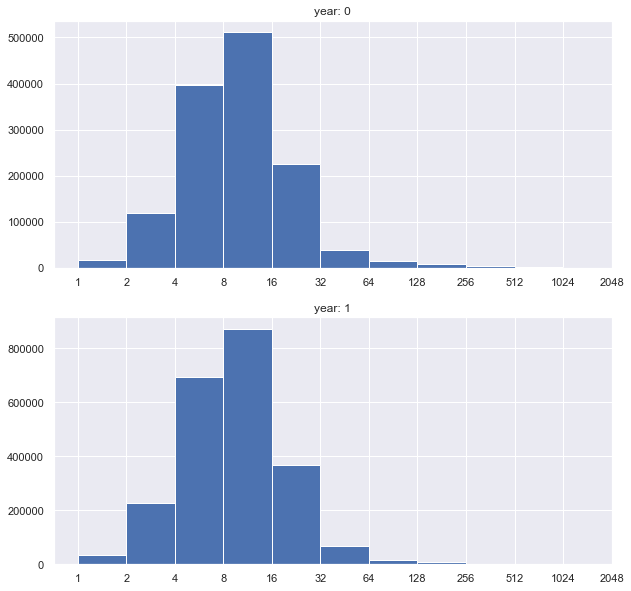

```python
data = trip_data[(trip_data.start_time >= '2017-07-01') &
                 (trip_data.start_time < '2019-07-01')]
data = data[['start_time', 'duration']]

data['year'] = 0
data.loc[(trip_data.start_time >= '2018-07-01') &
         (trip_data.start_time < '2019-07-01'), 'year'] = 1

# Duration in minutes rather than seconds
data.duration = data.duration.dt.total_seconds() / 60

# Bins for every doubling of 1 minute
bin_edges = 2 ** np.arange(0, np.log2(2048), 1)

fig, ax = plt.subplots(nrows=2, figsize=(10,10))

for i in range(2):
    ax[i].hist(data[data.year == i]['duration'], bins=bin_edges)
    ax[i].set_xscale('log', basex=2)
    xtick_locs = [1, 2, 4, 8, 16, 32, 64, 128, 256, 512, 1024, 2048]
    ax[i].set_xticks(xtick_locs)
    ax[i].set_xticklabels(xtick_locs)
    ax[i].set_title('year: ' + str(i))
```

*Interim Conclusion(s):*  
When comparing the first (full) year, with the second (with more users), we don't see a drastic change in duration of the trips.

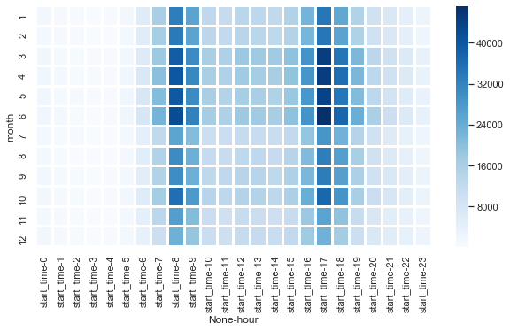

```python
data = trip_data[['start_time']].copy()
data['month'] = data.start_time.dt.month
data['hour'] = data.start_time.dt.hour
data = data.groupby(['month', 'hour']).count()
data = data.unstack()

plt.figure(figsize=(10, 5));
sb.heatmap(data, cmap='Blues', linewidth=2);
```

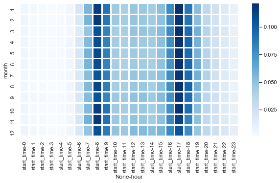

```python
data = trip_data[['start_time']].copy()
data['month'] = data.start_time.dt.month
data['hour'] = data.start_time.dt.hour
data = data.groupby(['month', 'hour']).count()
data = data.unstack()
data = data.apply(lambda r: r/r.sum(), axis=1)

plt.figure(figsize=(10, 5));
sb.heatmap(data, cmap='Blues', linewidth=2);
```

*Interim Conclusion(s):* One cannot see a drastic change in number of trips during the day in the course of a year. However, it looks a tiny bit like in December/in the Holiday season (when bikes are overall being used less) usage is a bit more spread out during the day.

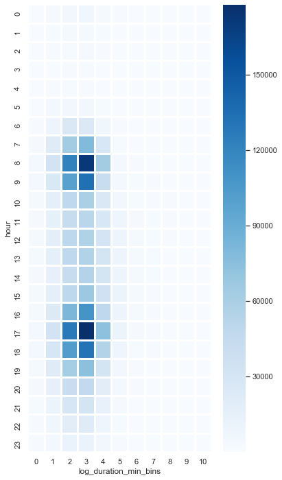

```python
data = trip_data[['start_time', 'duration']].copy()
data['hour'] = data.start_time.dt.hour
data['log_duration_min_bins'] = np.floor(np.log2(data.duration.dt.total_seconds()/60)).astype(int)
data = data.groupby(['hour', 'log_duration_min_bins']).count()['duration'].unstack()

plt.figure(figsize=(6, 12));
sb.heatmap(data, cmap='Blues', linewidth=2);
```

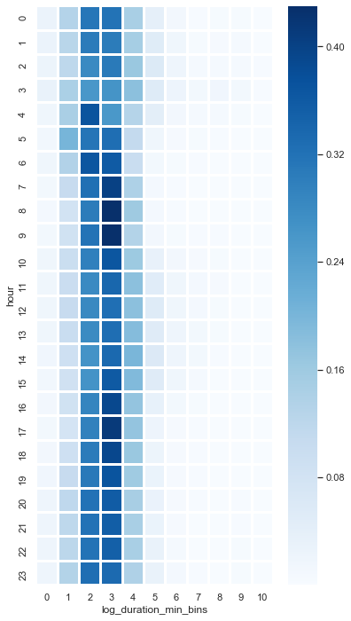

```python
data = trip_data[['start_time', 'duration']].copy()
data['hour'] = data.start_time.dt.hour
data['log_duration_min_bins'] = np.floor(np.log2(data.duration.dt.total_seconds()/60)).astype(int)
data = data.groupby(['hour', 'log_duration_min_bins']).count()['duration'].unstack()
data = data.apply(lambda r: r/r.sum(), axis=1)

plt.figure(figsize=(6, 12));
sb.heatmap(data, cmap='Blues', linewidth=2);
```

*Interim Conclusion(s):*  
Trip length/duration stays more or less the same during the day, with the minor exemption that trips very, very early in the moring (around 5 o'clock) are a bit shorter (going to get some rolls?).

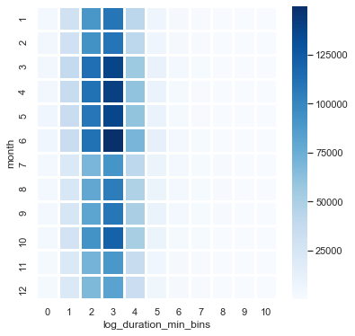

```python
data = trip_data[['start_time', 'duration']].copy()
data['month'] = data.start_time.dt.month
data['log_duration_min_bins'] = np.floor(np.log2(data.duration.dt.total_seconds()/60)).astype(int)
data = data.groupby(['month', 'log_duration_min_bins']).count()['duration'].unstack()

plt.figure(figsize=(6, 6));
sb.heatmap(data, cmap='Blues', linewidth=2);
```

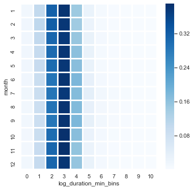

```python
data = trip_data[['start_time', 'duration']].copy()
data['month'] = data.start_time.dt.month
data['log_duration_min_bins'] = np.floor(np.log2(data.duration.dt.total_seconds()/60)).astype(int)
data = data.groupby(['month', 'log_duration_min_bins']).count()['duration'].unstack()
data = data.apply(lambda r: r/r.sum(), axis=1)

plt.figure(figsize=(6, 6));
sb.heatmap(data, cmap='Blues', linewidth=2);
```

*Interim Conclusion(s):*  
There's no significant change in duration in the course of a year.

### Interrelation of User and Time Related Features:

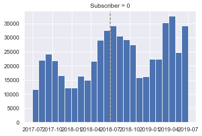

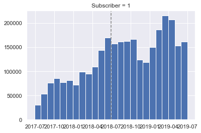

```python
data = trip_data[['subscriber', 'start_time']].copy()

for i in range(2):
    plt.hist(data[data.subscriber == i]['start_time'], bins=24)
    plt.title('Subscriber = ' + str(i))
    plt.axvline(x='07-01-2018', color='grey', linestyle='--')
    plt.show()
```

Interim conclusions:

- Trips with non-subscribers are more volatile.
- General growth in subscribers is bigger, but second (full year) is more or less stagnating.
- In May 2019 both, trips of subscribers and non-subscribers, dropped significantly, but only non-subscribers really bounced back in June 2019.

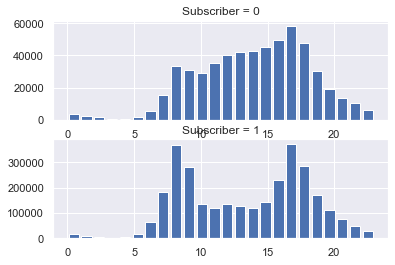

```python
data = trip_data[['subscriber', 'start_time']].copy()

data.start_time = data.start_time.dt.hour

fig, ax = plt.subplots(nrows=2)

for i in range(2):
    ax[i].hist(data[data.subscriber == i]['start_time'], bins=24, rwidth=0.8)
    ax[i].set_title('Subscriber = ' + str(i))
```

*Interim Conclusion(s):*  
Non-subscribers have a much more homogenous usage pattern during the day than subscribers that heavily use the bikes in peak hours.

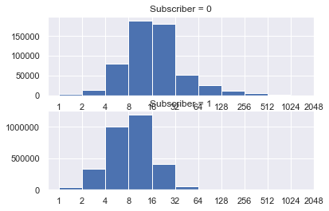

```python
data = trip_data[['subscriber', 'duration']].copy()

# Duration in minutes rather than seconds
data.duration = data.duration.dt.total_seconds() / 60

# Bins for every doubling of 1 minute
bin_edges = 2 ** np.arange(0, np.log2(2048), 1)

fig, ax = plt.subplots(nrows=2)

for i in range(2):
    ax[i].hist(data[data.subscriber == i]['duration'], bins=bin_edges)
    ax[i].set_xscale('log', basex=2)
    xtick_locs = [1, 2, 4, 8, 16, 32, 64, 128, 256, 512, 1024, 2048]
    ax[i].set_xticks(xtick_locs)
    ax[i].set_xticklabels(xtick_locs)
    ax[i].set_title('Subscriber = ' + str(i))
```

*Interim Conclusion(s):*  
Non-subscribers make longer use of the bikes than subscribers (which also generates additional fees!)